# Machine Learning_HW_1

Eunseok PARK

- 관련 파일 : Credit.csv
- 필요 패키지 :`dplyr`, `leaps`

## 1. **Data 생성**

```r
setwd("D:/[Machine Learning]/Machine Learning")
data <- read.csv('Credit.csv')
str(data)
```

```
## 'data.frame':    400 obs. of  12 variables:
##  $ X        : int  1 2 3 4 5 6 7 8 9 10 ...
##  $ Income   : num  14.9 106 104.6 148.9 55.9 ...
##  $ Limit    : int  3606 6645 7075 9504 4897 8047 3388 7114 3300 6819 ...
##  $ Rating   : int  283 483 514 681 357 569 259 512 266 491 ...
##  $ Cards    : int  2 3 4 3 2 4 2 2 5 3 ...
##  $ Age      : int  34 82 71 36 68 77 37 87 66 41 ...
##  $ Education: int  11 15 11 11 16 10 12 9 13 19 ...
##  $ Gender   : Factor w/ 2 levels " Male","Female": 1 2 1 2 1 1 2 1 2 2 ...
##  $ Student  : Factor w/ 2 levels "No","Yes": 1 2 1 1 1 1 1 1 1 2 ...
##  $ Married  : Factor w/ 2 levels "No","Yes": 2 2 1 1 2 1 1 1 1 2 ...
##  $ Ethnicity: Factor w/ 3 levels "African American",..: 3 2 2 2 3 3 1 2 3 1 ...
##  $ Balance  : int  333 903 580 964 331 1151 203 872 279 1350 ...
```

- Ethnicity 변수는 3개의 level을 가지고 있음
- 두개의 더미 변수로 바꾸어 주는 작업이 필요

```r
library(dplyr)
attach(data)
y <- Balance
data$Eth_AA <- (Ethnicity=="African American")*1
data$Eth_A <- (Ethnicity=="Asian")*1
x <- select(data, -X, -Balance, -Ethnicity)
```

- Ethinicity 변수를 두개의 더미 변수로 바꿈
  - Eth_AA : Ethnicity 변수가 African American 값을 갖음
  - Eth_A : Ethnicity 변수가 Asian 값을 갖음
- `dplyr package`의 select 함수를 이용하여 불필요한 변수 제거

## 2. **Best subset selection function**

> **각 값이 들어갈 Empty list 생성**

```r
combn.model <- list()
rss.model <- list()
rss <- list()
mse <- list()
foo <- list()
```

- Best subset selection의 방법에 사용되어지는 값들이 넣어질 Empty list를 생성
  - combn.model : 변수의 combination 값들이 들어감
  - rss.model : combination 되어진 모델들의 rss 값들이 들어감
  - rss : 모델 별 가장 작은 rss값들이 들어감
  - mse : 모델 별 가장 작은 mse값들이 들어감
  - foo : Best subset selection을 활용한 변수들이 들어감

> **`lm()`함수의 들어갈 formula 생성**

```r
df <- c()
for(i in 1:ncol(x)){
  if(i==1){
    var.names <- paste("x[,combn.model[[j]][,i]",'[',i,']]',sep='')
    df[i] <- paste('y~', var.names, sep='')
  }

  if(i!=1){
    df[i] <- paste(df[i-1] ,paste("x[,combn.model[[j]][,i]",'[',i,']]',sep=''), sep='+')
  }
}
```

- combn.model(변수들의 조합)의 index를 활용하여 `lm()`함수를 구현하기에 사전 formula를 작성함

> **Best subset selection 을 활용한 모델 선택**

```r
for(j in 1:ncol(x)){
  combn.model[[j]] <- combn(names(x), j)
  rss.model[[j]] <- matrix(NA, nrow = ncol(combn.model[[j]]))
  for(i in 1:ncol(combn.model[[j]])){
    rss.model[[j]][i,] <- sum(summary(lm(df[j]))$residuals^2)
    rss[[j]] <- min(rss.model[[j]])
    mse[[j]] <- rss[[j]]/nrow(x)
    foo[[j]] <- combn.model[[j]][ , which.min(rss.model[[j]])]
  }
  print(j)
}
```

```
## [1] 1
## [1] 2
## [1] 3
## [1] 4
## [1] 5
## [1] 6
## [1] 7
## [1] 8
## [1] 9
## [1] 10
## [1] 11
```

- 위 결과 값으로 Cp, AIC, BIC … 값들을 구할 수 있음

## 3. **Choosing the Optimal Model**

> **Cp 값 산출**

```r
cp <- list()

for(i in 1:ncol(x)){
  cp[[i]] <- (rss[[i]]+2*nrow(combn.model[[i]])*mse[[i]])/nrow(x)
}
```

> **AIC 값 산출**

```r
AIC <- list()

for(i in 1:ncol(x)){
  AIC[[i]] <- (rss[[i]]+2*nrow(combn.model[[i]])*mse[[i]])/(mse[[i]]*nrow(x))
}
```

> **BIC 값 산출**

```r
BIC <- list()

for(i in 1:ncol(x)){
  BIC[[i]] <-(rss[[i]]+(log(nrow(x))*nrow(combn.model[[i]])*mse[[i]]))/(mse[[i]]*nrow(x))
}
```

> **adj.R^2 값 산출**

```r
df.2 <- c()
for(i in 1:ncol(x)){
  if(i==1){
    var.names <- paste("x[,foo[[j]]",'[',i,']]',sep='')
    df.2[i] <- paste('y~', var.names, sep='')
  }

  if(i!=1){

    df.2[i] <- paste(df.2[i-1], paste("x[,foo[[j]]",'[',i,']]',sep=''), sep='+')
  }
}
```

- `lm()` 함수를 사용하기위한 사전 formula 생성

```r
R.adj <- list()
for(j in 1:ncol(x)){
  R.adj[j] <- summary(lm(df.2[j]))[9]
}
```

> **10-fold CV 값 산출**

```r
df.3 <- c()
df.3[1] <- paste('Balance ~ Rating')
df.3[2] <- paste('Balance ~ Income + Rating')
df.3[3] <- paste('Balance ~ Income + Rating + Student')
df.3[4] <- paste('Balance ~ Income + Limit + Cards + Student')
df.3[5] <- paste('Balance ~ Income + Limit + Rating + Cards + Student')
df.3[6] <- paste('Balance ~ Income + Limit + Rating + Cards + Age + Student')
df.3[7] <- paste('Balance ~ Income + Limit + Rating + Cards + Age + Gender + Student')
df.3[8] <- paste('Balance ~ Income + Limit + Rating + Cards + Age + Gender + Student + Eth_AA')
df.3[9] <- paste('Balance ~ Income + Limit + Rating + Cards + Age + Gender + Student + Married + Eth_AA')
df.3[10] <- paste('Balance ~ Income + Limit + Rating + Cards + Age + Education + Gender + Student + Married + Eth_AA')
df.3[11] <- paste('Balance ~ Income + Limit + Rating + Cards + Age + Education + Gender + Student + Married + Eth_AA + Eth_A')
```

- `lm()` 함수를 사용하기위한 사전 formula 생성

```r
k <- 10
data.fold <- sample(1:nrow(x), replace=F)
folds <- data.fold%%k
table(folds)
```

```
## folds
##  0  1  2  3  4  5  6  7  8  9
## 40 40 40 40 40 40 40 40 40 40
```

```r
mse.k <- matrix(NA, k, ncol(x))



for(j in 1:ncol(x)){
  for(i in 1:k){
    train.data <- data[folds != i-1, ]
    test.data <- data[folds == i-1, ]
    y.hat <- predict(lm(df.3[j], train.data), test.data[,c("Balance", foo[[j]])])
    mse.k[i,j] <- sum((test.data$Balance - y.hat)^2)/nrow(test.data)
  }
  print(j)
}
```

```
## [1] 1
## [1] 2
## [1] 3
## [1] 4
## [1] 5
## [1] 6
## [1] 7
## [1] 8
## [1] 9
## [1] 10
## [1] 11
```

```r
mse.res <- colMeans(mse.k)
```

## 4. **모델 별 Cp, adj.R^2, 10-fold CV**

```r
no.pre <- 1:ncol(x)
```

- plot의 x축 값들을 생성

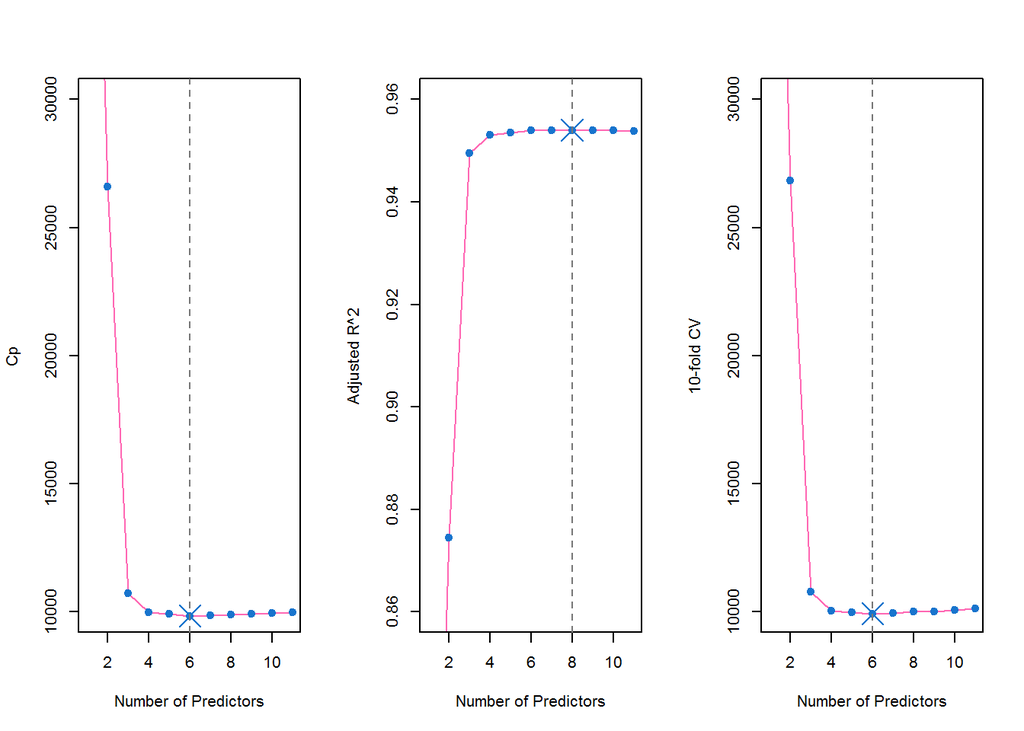

```r
par(mfrow=c(1,3))

plot(no.pre, cp, type = "o" , lty = 1, pch = 21, col = "hotpink" ,
     ylim = c(10000, 30000), xlab = "Number of Predictors", ylab = "Cp", bg="dodgerblue3")
points(no.pre, cp, col="dodgerblue3")
points(which.min(cp), cp[[which.min(cp)]], col="dodgerblue3", cex=3, pch=4)
abline(0, 0, v = which.min(cp), lty = 2, col = "grey47")

plot(no.pre, R.adj, type = "o" , lty = 1, pch = 21, col = "hotpink",
     ylim = c(0.86, 0.96), xlab = "Number of Predictors", ylab = "Adjusted R^2", bg="dodgerblue3")
points(no.pre, R.adj, col="dodgerblue3")
points(which.max(R.adj), R.adj[[which.max(R.adj)]], col="dodgerblue3", cex=3, pch=4)
abline(0, 0, v = which.max(R.adj), lty = 2, col = "grey47")

plot(no.pre, mse.res, type = "o" , lty = 1, pch = 21, col = "hotpink",
     ylim = c(10000, 30000), xlab = "Number of Predictors", ylab = "10-fold CV", bg="dodgerblue3")
points(no.pre, mse.res, col="dodgerblue3")
points(which.min(mse.res), mse.res[[which.min(mse.res)]], col="dodgerblue3", cex=3, pch=4)
abline(0, 0, v = which.min(mse.res), lty = 2, col = "grey47")
```

> **BIC 값 산출(강의 노트에 나와 있는 식)**

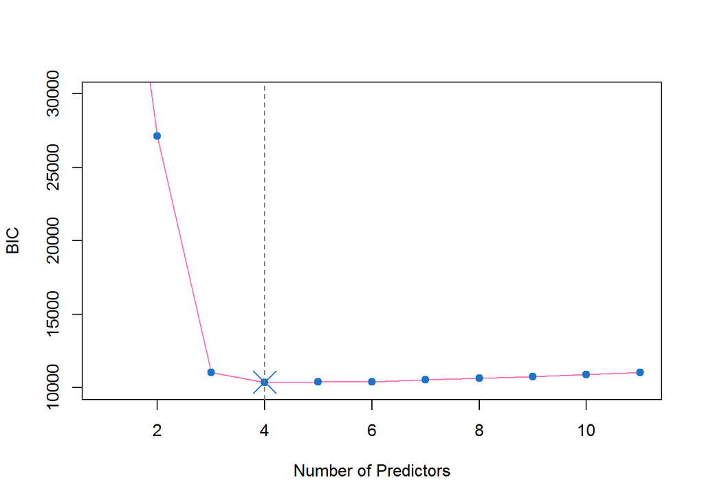

```r
BIC2 <- list()

for(i in 1:ncol(x)){
  #i=1
  BIC2[[i]] <-(rss[[i]]+(log(nrow(x))*nrow(combn.model[[i]])*mse[[i]]))/nrow(x)
}

plot(no.pre, BIC2, type = "o" , lty = 1, pch = 21, col = "hotpink",
     ylim = c(10000, 30000), xlab = "Number of Predictors", ylab = "BIC", bg="dodgerblue3")
points(no.pre, BIC2, col="dodgerblue3")
points(which.min(BIC2), BIC2[[which.min(BIC2)]], col="dodgerblue3", cex=3, pch=4)
abline(0, 0, v = which.min(BIC2), lty = 2, col = "grey47")
```

## 5. **`leaps package`를 활용한 model selection**

```r
library(leaps)
regfit.full <- regsubsets(y~., x, nvmax = 11)
regfit.forward <- regsubsets(y~., x, nvmax = 11, method = 'forward')
reg.summary <- summary(regfit.full)
reg.summary.forward <- summary(regfit.forward)
```

- `reg subsets()`를 이용하여 model selection이 가능함
  - method = … : forward, backward (default : Best subset)

```r
reg.summary$rss
```

```
##  [1] 21435122 10532541  4227219  3915058  3866091  3821620  3810759
##  [8]  3800969  3794145  3789709  3786730
```

```r
unlist(rss)
```

```
##  [1] 21435122 10532541  4227219  3915058  3866091  3821620  3810759
##  [8]  3800969  3794145  3789709  3786730
```

- `reg subset()`으로 구한 rss값과 위에서 구한 rss 값을 비교

```r
reg.summary$cp
```

```
##  [1] 1800.308  685.197   41.134   11.149    8.132    5.575    6.462
##  [8]    7.459    8.760   10.305   12.000
```

```r
unlist(cp)
```

```
##  [1] 53856 26595 10727  9983  9907  9841  9860  9883  9912  9948  9988
```

- `reg subset()`으로 구한 cp값과 위에서 구한 cp 값을 비교

```r
reg.summary$bic
```

```
##  [1]  -535.9  -814.2 -1173.4 -1198.1 -1197.1 -1195.7 -1190.9 -1185.9
##  [9] -1180.6 -1175.1 -1169.4
```

```r
unlist(BIC2)
```

```
##  [1] 54390 27120 11043 10374 10389 10413 10526 10641 10764 10893 11027
```

- `reg subset()`으로 구한 BIC값과 위에서 구한 BIC 값을 비교

```r
reg.summary$adjr2
```

```
##  [1] 0.7452 0.8745 0.9495 0.9531 0.9536 0.9540 0.9540 0.9540 0.9540 0.9539
## [11] 0.9538
```

```r
unlist(R.adj)
```

```
##  [1] 0.7452 0.8745 0.9495 0.9531 0.9536 0.9540 0.9540 0.9540 0.9540 0.9539
## [11] 0.9538
```

- `reg subset()`으로 구한 adj.R^2값과 위에서 구한 adj.R^2 값을 비교

```r
coef(regfit.full, 4)
```

```
## (Intercept)      Income       Limit       Cards  StudentYes
##   -499.7272     -7.8392      0.2666     23.1754    429.6064
```

- 선정된 모델을 볼 수 있음